# Колку тежи македонскиот парламент? Дел 1: Родова анализа

DiscindoDataBrew

## За

Овој документ прикажува податоци за имот на пратеници во Република Македонија објавени од страна на Државната комисија за спречување на корупцијата по конституирање на новиот парламентарен состав во декември 2016.

Податоците се за 100 пратеници бидејќи на веб-сајтот на комисијата до со 24.02.2017 само толку анкетни листови се објавени/ажурирани.

Ако најдете грешки, пријавете [тука](https://github.com/novica/databrew/issues). Изворниот код може да се преземе [тука](https://github.com/novica/databrew/).

## Вовед

Во Собранието на Република Македонија има 120 пратеници. Вкупниот сооднос е 38 жени и 82 мажи. Подолу се податоци за 100 од нив: 28 жени и 72 мажи.

### Вкупно имот по тип

Македонските пратеници и нивните семејства најмногу поседуваат недвижен имот. Всушност сите други видови на имот се на износ близу до долговите што ги имаат пратениците, па така 24-те милиони евра се горе-долу вредноста на недвижниот имот.

Табела 1: Вкупно имот во евра по тип на имот

| Имот | Вкупно |
| --- | --- |
| Недвижен имот | 24.618.637 |
| Долгови | 4.677.112 |
| Подвижен имот | 2.153.051 |
| Банкарски депозити | 1.114.695 |
| Хартии од вредност | 677.997 |
| Побарувања | 423.120 |
| Друг имот | 330.007 |
| Други приходи | 94.468 |

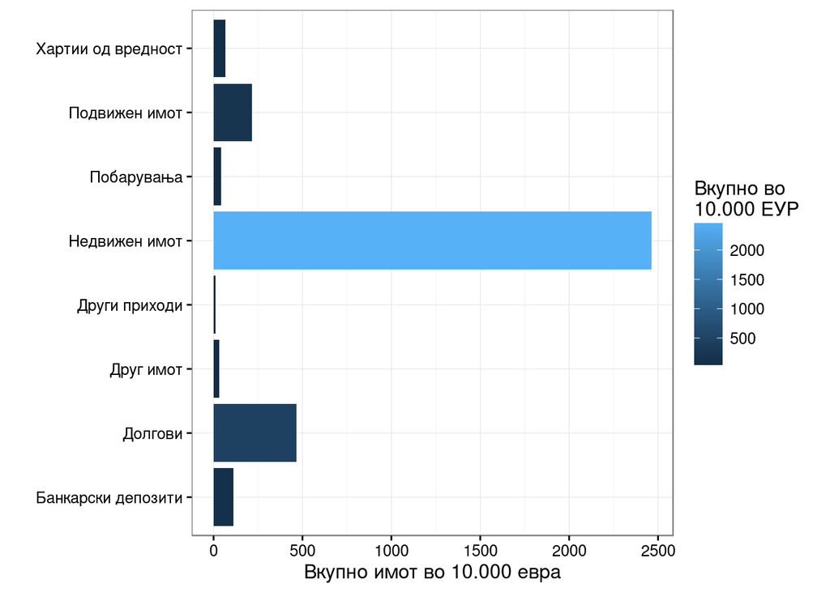

Слика 1: Вкупно имот по тип на имот

### Родова распределба на имотот

Родовата распределба на имотот открива јаз помеѓу мажите и жените во собранието, односно помеѓу нив и брачните другари. Табелите подолу го покажуваат вкупниот имот по тип на имот со кој што располагаат пратениците и брачните другари на пратеничките, односно пратеничките и брачните другари на пратениците.

Најинтересен е податокот дека жените: пратеничките + брачните другари на пратениците, се главните носители на задолженоста во Собранието.

Табела 2: Вкупно имот по тип на имот во сопственост на мажи

| Имот | Вкупно |
| --- | --- |
| Недвижен имот | 11.115.829 |
| Подвижен имот | 1.452.746 |
| Банкарски депозити | 574.827 |
| Долгови | 567.833 |
| Хартии од вредност | 452.392 |
| Побарувања | 206.448 |
| Друг имот | 76.637 |
| Други приходи | 59.365 |

Табела 3: Вкупно имот по тип на имот во сопственост на жени

| Имот | Вкупно |
| --- | --- |
| Долгови | 3.752.296 |
| Недвижен имот | 2.166.799 |
| Банкарски депозити | 341.874 |
| Подвижен имот | 289.235 |
| Побарувања | 78.049 |
| Друг имот | 47.250 |
| Хартии од вредност | 27.308 |
| Други приходи | 2.917 |

Подетална анализа на имотите укажува на тоа дека пратеничките и жените на пратениците се во значително понеповолна имотна состојба од нивните машки колеги. И брачните другари на пратеничките и нивните родители имаат повеќе нето имот од пратеничките. Пратеничките воглавно, и најмногу во однос на сите други, имаат долгови.

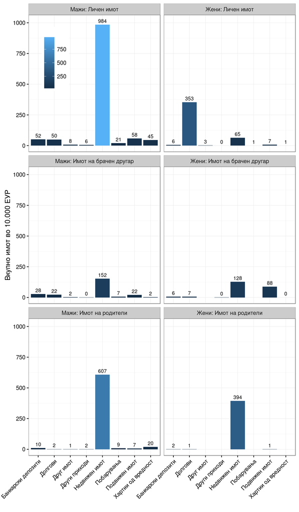

Слика 2: Родова распределба на имот

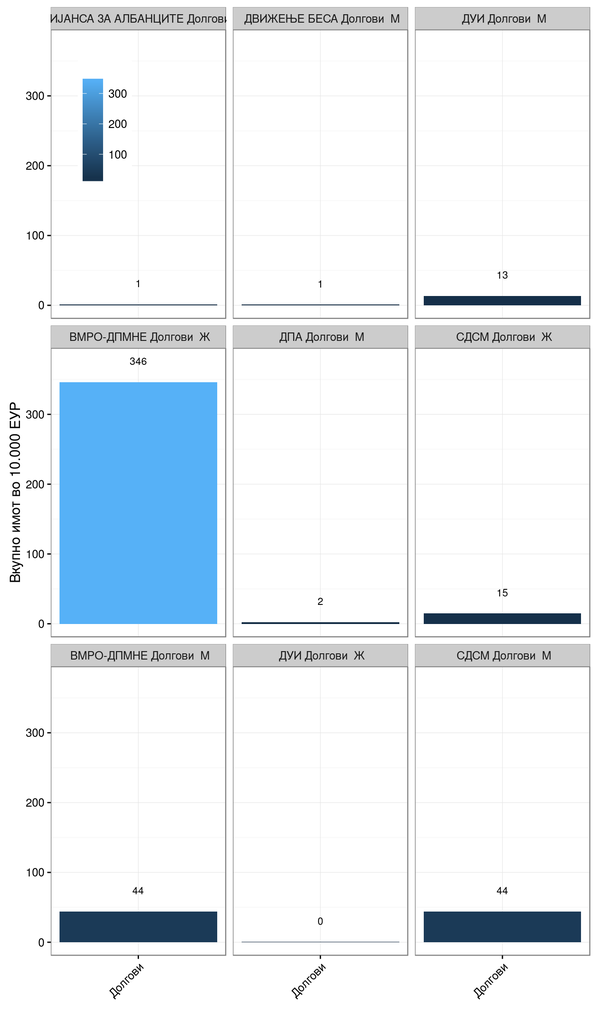

Слика 3: Родова2 распределба на имот

Дополнето 28.02.2017: Сепак, главниот „должник“ помеѓу сите жени е само една пратеничка. Доколку не станува грешка во податоците објавени од ДКСК тоа е пратеничката Нола Исмајлоска Старова која што има заведено долг од 3,4 милиони евра. Овој долг настанал помеѓу 3 април 2016 кога бил поднесен [претходниот анкетен лист](https://data-mkopen.rhcloud.com/diff/+xhLVIsvfe+AQq5agPdMYw) и 1 февруари 2017 кога е поднесен [новиот анкетен лист](http://www.dksk.org.mk/imoti_2/detail.php?detail=11607&search=&ime=%D0%BD%D0%BE%D0%BB%D0%B0&prezime=&funkcija=&institucija=).